# Лабораторная работа 3.

## Требуется:

- Определить (используя 3 ранее изученных метода классификации), к какому классу следует отнести фирму с показателями: x1 = 740, x2 = 590
- Провести исследование результатов работы алгоритмов классификации в зависимости от параметров используемых методов.
- Сравнить результаты полученные тремя методами, сделать вывод.
- Предложить (с обоснованием) наиболее подходящий метод решения задачи.

## Исходные данные:

csv файл:

[figure not shown]

рисунок с представленными данными:

[figure not shown]

## Методы решения задачи классификации:

### Суть метода k-ближайших соседей

Метод k ближайших соседей (англ. k-nearest neighbor algorithm) - метод автоматической классификации объектов. Основным принципом метода ближайших соседей является то, что объект присваивается тому классу, который является наиболее распространённым среди соседей данного элемента.

Соседи берутся исходя из множества объектов, классы которых уже известны, и, исходя из ключевого для данного метода значения k высчитывается, какой класс наиболее многочислен среди них.

### Суть наивного байесовского алгоритма

Наивный байесовский алгоритм — это вероятностный алгоритм машинного обучения, основанный на применении теоремы Байеса и используемый в самых разных задачах классификации.

$$ P(A|B)=\frac{P(B|A)*P(A)}{P(B)}\\ $$

- P(A|B) - вероятность гипотезы А при наступлении события В, т. е. вероятность А, когда В уже верно;
- P(B|A) - вероятность наступления события В, если гипотеза А верна;
- P(A) - вероятность того, что гипотеза А верна;
- P(B) - вероятность наступления события В;

### SVM

Метод опорных векторов (Support Vector Machine - SVM) относится к группе граничных методов. Она определяет классы при помощи границ областей.

При помощи данного метода решаются задачи бинарной классификации.

В основе метода лежит понятие плоскостей решений.

Плоскость (plane) решения разделяет объекты с разной классовой принадлежностью.

```python
import pandas as pd
import matplotlib.pyplot as plt
import numpy as np
from sklearn.datasets import make_blobs
from sklearn.svm import SVC
from sklearn.neighbors import KNeighborsClassifier
from sklearn.naive_bayes import GaussianNB
```

```python
data = pd.read_csv('nalogs.csv')
testdata=[[740,590]]
data
```

|  | x1 | x2 | class |
| --- | --- | --- | --- |
| 0 | 740 | 680 | 0 |
| 1 | 670 | 600 | 0 |
| 2 | 560 | 550 | 0 |
| 3 | 540 | 520 | 0 |
| 4 | 590 | 540 | 0 |
| 5 | 590 | 700 | 0 |
| 6 | 470 | 600 | 0 |
| 7 | 560 | 540 | 0 |
| 8 | 540 | 630 | 0 |
| 9 | 500 | 600 | 0 |
| 10 | 750 | 590 | 1 |
| 11 | 360 | 600 | 1 |
| 12 | 720 | 750 | 1 |
| 13 | 540 | 710 | 1 |
| 14 | 570 | 700 | 1 |
| 15 | 520 | 670 | 1 |
| 16 | 590 | 790 | 1 |
| 17 | 670 | 700 | 1 |
| 18 | 620 | 730 | 1 |
| 19 | 690 | 840 | 1 |
| 20 | 610 | 680 | 1 |
| 21 | 550 | 730 | 1 |
| 22 | 590 | 750 | 1 |

```python
x1 = np.array(data['x1'])
x2 = np.array(data['x2'])
cl = np.array(data['class'])
X = pd.DataFrame({"A": x1, "B": x2}).to_numpy()
```

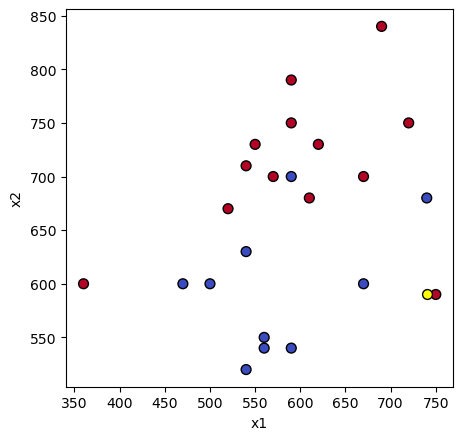

```python
plt.figure(figsize=(5,5), dpi=100)
plt.xlabel("x1")
plt.ylabel("x2")
plt.scatter(x1, x2, c=cl, edgecolor="black", s=50, cmap='coolwarm')
plt.scatter(740, 590, s=50, color = 'yellow', edgecolor="black")
```

## SVM

```python
clf=SVC(kernel='linear')
clf.fit(X,cl)
print(clf.predict(testdata))
```

```
[0]
```

## kNN

```python
neigh = KNeighborsClassifier(n_neighbors=3)
neigh.fit(X, cl)
print(neigh.predict(testdata))
```

```
[0]
```

## GaussianNB

```python
clfNB=GaussianNB()
clfNB.fit(X,cl)
print(clf.predict(testdata))
```

[output not shown]

# Список литературы

1. Описание функции KNeighborsClassifier https://scikit-learn.org/stable/modules/generated/sklearn.neighbors.KNeighborsClassifier.html
2. Описание Support Vector Machines https://scikit-learn.org/stable/modules/svm.html
3. Описание Gaussian Naive Bayes https://scikit-learn.org/stable/modules/naive_bayes.html